# King County Food Establishment Safety

This dashboard explores the King County Food Establishment Inspection dataset.  
Each row of the original dataset represents an inspection of a food establishment, including its score, result (Satisfactory/Unsatisfactory), location, and any violations recorded.

We aim to understand:

- How often inspections are unsatisfactory
- Where in King County food safety issues are concentrated
- What factors most commonly contribute to high-risk and low-risk health violations

A food safety rating of 0 is best. The classification of “Excellent”, “Good”, and “Okay” depends on both the rating, the Food Service Establishment Risk Level, and the timeframe of inspections  
being taken into account. An in-depth explanation of what goes into a restaurant’s rating can be found at the [King County Department of Public Health](https://kingcounty.gov/en/dept/dph/health-safety/food-safety/inspection-rating-system/rating-system).

Total Inspections

278,425

Unique Businesses

12,874

Overall Unsatisfactory Rate

44.4%

Avg Inspection Score

14

Distribution of Inspection Scores

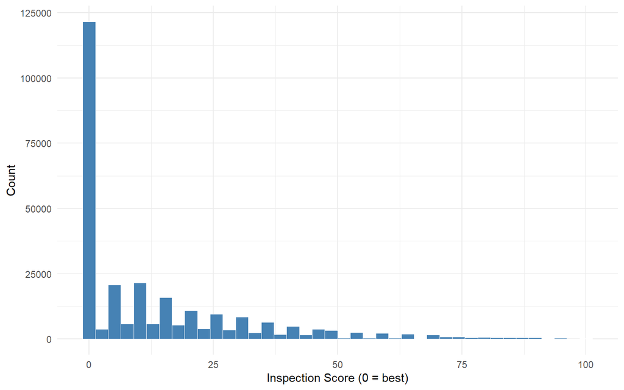

Inspection Outcomes

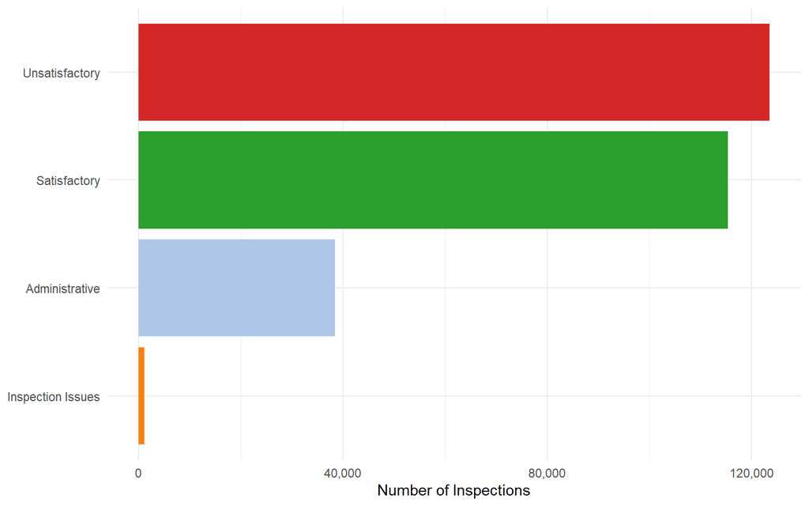

This page explores the geographic distribution of food inspection results across King County. Each point represents an individual inspection record — **red = unsatisfactory, green = satisfactory**.

King County Inspection Outcomes Map

[interactive chart not shown]

This page breaks down unsatisfactory result rates geographically, by city and by ZIP code. This identifies communities in King County with the highest concentration of food safety issues.

Unsatisfactory Rate by City (≥ 200 inspections)

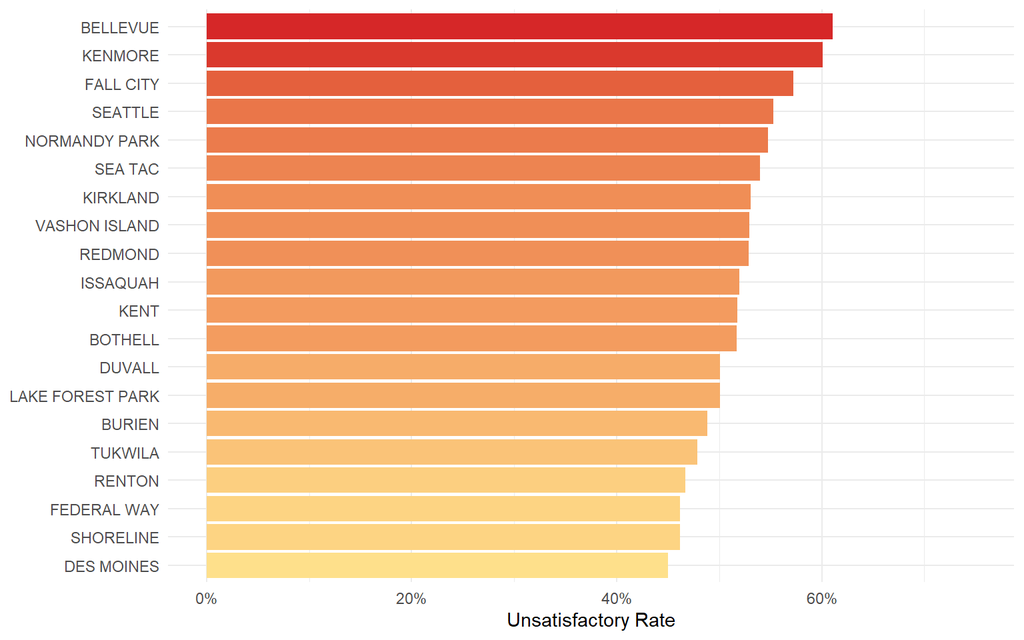

ZIP Code Summary Table

| Zip.Code | Inspections | Unsatisfactory | Unsatisfactory Rate | Avg Score |
| --- | --- | --- | --- | --- |
| 98105 | 9488 | 6141 | 64.7% | 22.4 |
| 98104 | 8413 | 5599 | 66.6% | 26 |
| 98052 | 9068 | 4986 | 55% | 18.3 |
| 98004 | 7324 | 4767 | 65.1% | 21.5 |
| 98101 | 8104 | 4368 | 53.9% | 15.6 |
| 98122 | 7172 | 4072 | 56.8% | 16.1 |
| 98118 | 6174 | 3924 | 63.6% | 21 |
| 98003 | 8090 | 3784 | 46.8% | 12.8 |
| 98103 | 6405 | 3320 | 51.8% | 15.2 |
| 98107 | 5396 | 3159 | 58.5% | 15.9 |

[output cut: 71 more lines]

How have inspection outcomes changed over the years? This page tracks unsatisfactory result rates and inspection volumes over time across all of King County.

Annual Unsatisfactory Rate Over Time

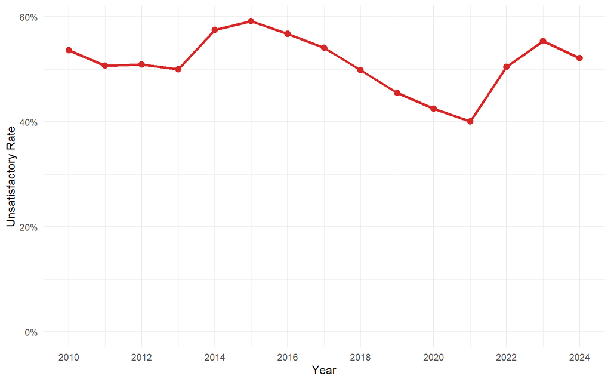

Annual Inspection Volume

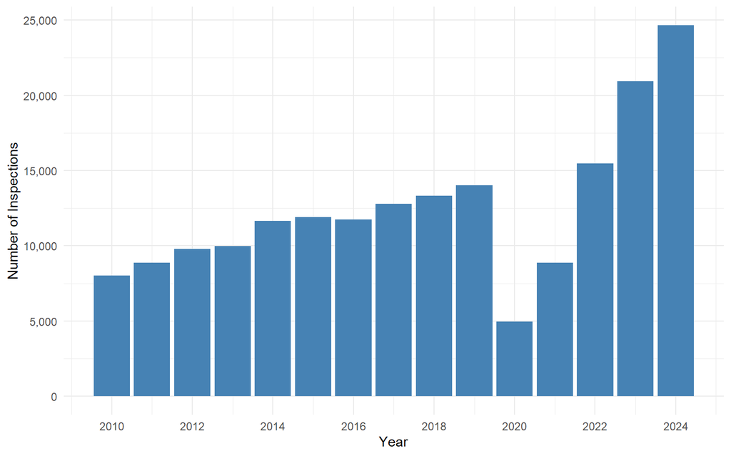

Unsatisfactory Rate by Month (All Years)

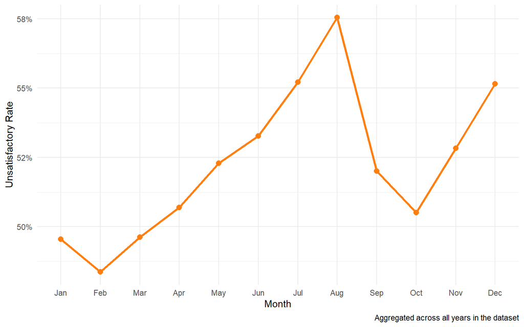

This page examines the proportion of individual **RED** (critical) vs **BLUE** (non-critical) violations. Per King County, Red violations directly cause food-borne illnesses (improper temperatures, poor hygiene for example), while blue violations cover maintenance and sanitation.

RED Violations

81,215

BLUE Violations

74,857

RED vs BLUE Violation Proportion by Establishment Category

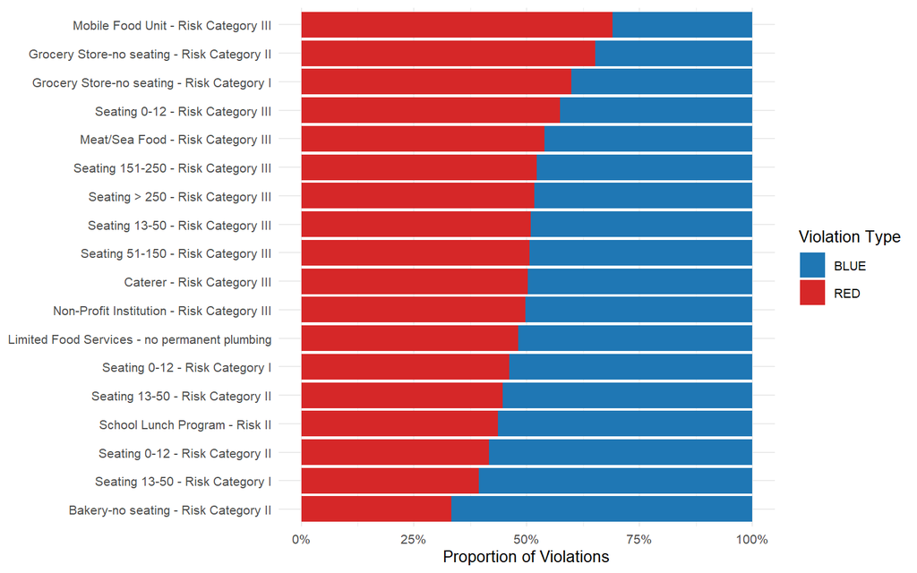

RED vs BLUE Proportion by City (>= 200 violations)

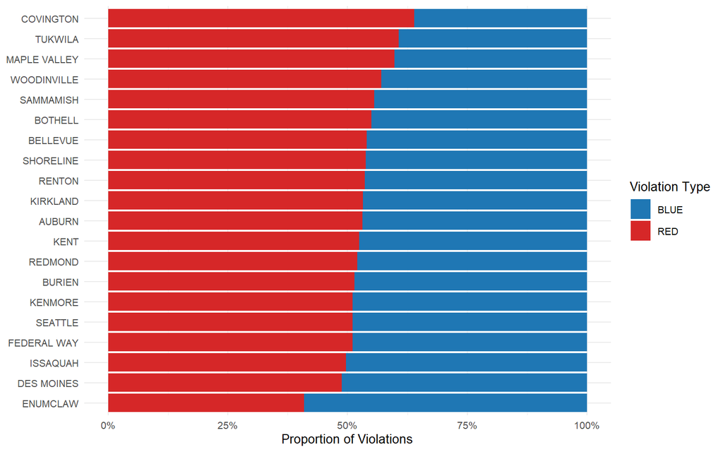

Analysis of King County food establishment inspection data reveals several notable patterns in food safety across the region.

**Overall Inspection Outcomes**  
Unsatisfactory results are common; roughly half of all inspection records in the dataset are flagged as unsatisfactory.  
However, this figure should be interpreted carefully, as each inspection visit can generate multiple rows (one per violation cited),  
which inflates the raw rate. A single establishment visit with three violations counts three times toward the unsatisfactory total.

**Geographic Concentration**  
Food safety issues are not evenly distributed across King County. Cities including Bellevue, Kenmore, and Fall City show the highest  
unsatisfactory rates among jurisdictions with a sufficient inspection count. This may reflect differences in establishment density, inspection  
frequency, or the mix of establishment types operating in each area rather than differences in food safety culture alone.

**Official King County Resources**

- [King County Food Safety Program](https://kingcounty.gov/en/dept/dph/health-safety/food-safety)
- [Inspection Rating System Explained](https://kingcounty.gov/en/dept/dph/health-safety/food-safety/inspection-rating-system/rating-system)
- [Search Restaurant Inspection Results](https://kingcounty.gov/en/dept/dph/health-safety/food-safety/inspection-results)